# Study2 Analysis

Investigating the influence of the agent’s Power on the Side-Effect Effect

Bradley Kennedy

# Study Information

This preregistered study was a online study conducted through Qualtrics. The study investigated how intention is viewed. That is, whether or not an action was planned. Additionally, it investigated how much particular actions deserve praise or blame.

In the study, vignettes were presented to participants. These vignettes varied with the amount of power that the main character (agent) possessed. Additionally, the side-effect was varied between helpful and harmful. For example vignettes, see the OSF repository.

Preregistration, materials, analysis code and a copy of the anonymised data will be made publically available on the Open Science Framework, links below.

OSF Repository: https://osf.io/u3j4y/  
OSF Preregistration: https://osf.io/9j6w4

# R Set-up

Current R Version: 4.1.0

Check if required packages need to be installed, if so, install

```r
list_of_packages<-c("tidyverse","plyr", "dplyr", "here", "ordinal", "emmeans", "Hmisc")
new.packages <-
  list_of_packages[!(list_of_packages %in% installed.packages()[,"Package"])]
if(length(new.packages))install.packages(new.packages)

lapply(list_of_packages, library, character.only = TRUE)
```

Check for package updates from cloud.r-project.org

```r
update.packages(ask=FALSE, repos = "https://cloud.r-project.org")
```

Import Data & Set variables

```r
s2data <- read_csv(here("DataWrangling","cleaned_s2data.csv"), col_types =
                     cols(List = col_factor(levels = c("1", "2", "3", "4")),
                          Question = col_factor(levels = c("int", "pb")),
                          Power = col_factor(levels = c("high", "low")),
                          SEValence = col_factor(levels = c("help", "harm"))))

# Plot data set-up
PlotData <- s2data
PlotData$SEValence <- PlotData$SEValence %>%
  as.factor() %>%
  revalue(c("help"="Helpful", "harm"="Harmful"))
PlotData$Power <- PlotData$Power %>%
  as.factor() %>%
  revalue(c("low"="Low power", "high"="High power"))

s2data$Age <- as.numeric(s2data$Age)
s2data$Gender <- tolower(s2data$Gender)
s2data$Gender <- as.factor(s2data$Gender)
s2data$Student_status <- as.factor(s2data$Student_status)
s2data$Job <- as.factor(s2data$Job)

# Filters for (1) Blame/Praise and (2) Intentionality for the main analysis
filterPB <- s2data$Question == "pb"
filterInt <- s2data$Question == "int"

# This creates the ordered factor for the Rating variable which is Likert scale
s2data$Rating <- as.ordered(s2data$Rating)

# Creates factors for the random effects
s2data$Participant <- as.factor(s2data$Participant)
s2data$Item <- as.factor(s2data$Item)

# This centres the fixed factors using deviation coding
contrasts(s2data$Power) <- matrix(c(.5, -.5))
contrasts(s2data$SEValence) <- matrix(c(.5, -.5))
```

# Analysis

## Cumulative Link Mixed Models

Christensen, R. H. B. (2019). ordinal - Regression Models for Ordinal Data. R package version 2019.12-10. https://CRAN.R-project.org/package=ordinal.

### Praise Blame model

DV is `Rating` which is the Likert scale response of assigning degree of Praise or Blame (0 to 6) `Power` is the Agent’s Job Power level experimental factor (levels high & low) `SEValence` is the Side Effect Valence experimental factor (level HE = helpful; level HA = harmful)

```r
PB_Model <- clmm(Rating ~ Power * SEValence + (1 + Power * SEValence | Participant) +
                   (1 + Power * SEValence | Item), data = s2data[filterPB,])
summary(PB_Model)
```

```
## Cumulative Link Mixed Model fitted with the Laplace approximation
##
## formula: Rating ~ Power * SEValence + (1 + Power * SEValence | Participant) +
##     (1 + Power * SEValence | Item)
## data:    s2data[filterPB, ]
##
##  link  threshold nobs logLik   AIC      niter       max.grad cond.H
##  logit flexible  3200 -5343.82 10745.64 5203(39543) 2.75e-03 4.3e+02
##
## Random effects:
##  Groups      Name                   Variance Std.Dev. Corr
##  Participant (Intercept)            1.8332   1.3540
##              Powerlow               0.3722   0.6101   -0.300
##              SEValenceharm          3.9722   1.9930   -0.636 -0.215
##              Powerlow:SEValenceharm 1.4684   1.2118    0.067  0.174 -0.247
##  Item        (Intercept)            1.5346   1.2388
##              Powerlow               2.6650   1.6325   -0.826
##              SEValenceharm          1.7992   1.3413   -0.710  0.552
##              Powerlow:SEValenceharm 3.4049   1.8452    0.541 -0.706 -0.783
## Number of groups:  Participant 100,  Item 32
##
## Coefficients:
##                   Estimate Std. Error z value Pr(>|z|)
## Power1             -0.5268     0.2605  -2.022 0.043129 *
## SEValence1         -1.0141     0.2801  -3.620 0.000294 ***
## Power1:SEValence1   0.9453     0.4302   2.197 0.027993 *
## ---
## Signif. codes:  0 '***' 0.001 '**' 0.01 '*' 0.05 '.' 0.1 ' ' 1
##
## Threshold coefficients:
##     Estimate Std. Error z value
## 0|1 -3.67025    0.16372 -22.418
## 1|2 -2.40093    0.15062 -15.940
## 2|3 -1.15937    0.14520  -7.984
## 3|4  0.09645    0.14374   0.671
## 4|5  1.68265    0.14714  11.436
## 5|6  3.11988    0.15684  19.892
```

```r
# This produces the pairwise comparisons for the Praise Blame Model for the interaction of Agent Power (Power) and Side Effect Valence (SEValence)
emmeans(PB_Model, pairwise ~ Power * SEValence, adjust = "none")
```

```
## $emmeans
##  Power SEValence  emmean    SE  df asymp.LCL asymp.UCL
##  high  help      -0.1455 0.298 Inf    -0.729     0.438
##  low   help      -0.0914 0.251 Inf    -0.583     0.400
##  high  harm       0.3959 0.262 Inf    -0.117     0.909
##  low   harm       1.3954 0.228 Inf     0.949     1.842
##
## Confidence level used: 0.95
##
## $contrasts
##  contrast              estimate    SE  df z.ratio p.value
##  high help - low help   -0.0541 0.355 Inf  -0.152  0.8790
##  high help - high harm  -0.5414 0.367 Inf  -1.477  0.1396
##  high help - low harm   -1.5409 0.383 Inf  -4.024  0.0001
##  low help - high harm   -0.4873 0.382 Inf  -1.275  0.2022
##  low help - low harm    -1.4867 0.339 Inf  -4.381  <.0001
##  high harm - low harm   -0.9995 0.319 Inf  -3.130  0.0017
```

```r
# This produces the confidence intervals for the main effects and the interaction for the Praise Blame Model
confint(PB_Model)
```

```
##                        2.5 %      97.5 %
## 0|1               -3.9911415 -3.34936826
## 1|2               -2.6961461 -2.10570860
## 2|3               -1.4439661 -0.87477419
## 3|4               -0.1852718  0.37817253
## 4|5                1.3942579  1.97104225
## 5|6                2.8124770  3.42728780
## Power1            -1.0372845 -0.01627745
## SEValence1        -1.5631059 -0.46504724
## Power1:SEValence1  0.1021429  1.78853926
```

### Intentionality model

```r
Int_Model <- clmm(Rating ~ Power * SEValence + (1 + Power * SEValence | Participant) +
                    (1 + Power * SEValence | Item), data = s2data[filterInt,])

summary(Int_Model)
```

```
## Cumulative Link Mixed Model fitted with the Laplace approximation
##
## formula: Rating ~ Power * SEValence + (1 + Power * SEValence | Participant) +
##     (1 + Power * SEValence | Item)
## data:    s2data[filterInt, ]
##
##  link  threshold nobs logLik   AIC      niter       max.grad cond.H
##  logit flexible  3200 -5387.78 10833.57 4817(33502) 2.81e-03 4.4e+02
##
## Random effects:
##  Groups      Name                   Variance Std.Dev. Corr
##  Participant (Intercept)            2.1683   1.4725
##              Powerlow               0.5457   0.7387   -0.603
##              SEValenceharm          3.3289   1.8245   -0.425 -0.322
##              Powerlow:SEValenceharm 0.6615   0.8134    0.024  0.626 -0.270
##  Item        (Intercept)            1.3951   1.1811
##              Powerlow               2.3999   1.5492   -0.824
##              SEValenceharm          1.6402   1.2807   -0.766  0.591
##              Powerlow:SEValenceharm 2.9844   1.7275    0.640 -0.735 -0.830
## Number of groups:  Participant 100,  Item 32
##
## Coefficients:
##                   Estimate Std. Error z value Pr(>|z|)
## Power1             -0.5321     0.2488  -2.138   0.0325 *
## SEValence1         -1.0019     0.2568  -3.902 9.54e-05 ***
## Power1:SEValence1   0.7637     0.4017   1.901   0.0573 .
## ---
## Signif. codes:  0 '***' 0.001 '**' 0.01 '*' 0.05 '.' 0.1 ' ' 1
##
## Threshold coefficients:
##     Estimate Std. Error z value
## 0|1  -3.3672     0.1671 -20.153
## 1|2  -2.0222     0.1569 -12.886
## 2|3  -0.4670     0.1527  -3.058
## 3|4   0.6192     0.1529   4.051
## 4|5   1.9538     0.1566  12.474
## 5|6   3.3218     0.1670  19.897
```

```r
# This produces the pairwise comparisons for the Intentionality Model for the interaction of Agent Job Power (Power) and Side Effect Valence (SEValence)
emmeans(Int_Model, pairwise ~ Power * SEValence, adjust = "none")
```

```
## $emmeans
##  Power SEValence  emmean    SE  df asymp.LCL asymp.UCL
##  high  help      -0.5825 0.295 Inf    -1.160  -0.00487
##  low   help      -0.4323 0.239 Inf    -0.902   0.03701
##  high  harm       0.0376 0.258 Inf    -0.468   0.54284
##  low   harm       0.9515 0.217 Inf     0.526   1.37713
##
## Confidence level used: 0.95
##
## $contrasts
##  contrast              estimate    SE  df z.ratio p.value
##  high help - low help    -0.150 0.344 Inf  -0.436  0.6626
##  high help - high harm   -0.620 0.345 Inf  -1.796  0.0725
##  high help - low harm    -1.534 0.352 Inf  -4.354  <.0001
##  low help - high harm    -0.470 0.363 Inf  -1.295  0.1952
##  low help - low harm     -1.384 0.306 Inf  -4.529  <.0001
##  high harm - low harm    -0.914 0.293 Inf  -3.117  0.0018
```

```r
# This produces the confidence intervals for the main effects and the interaction for the Intentionality Model
confint(Int_Model)
```

```
##                         2.5 %      97.5 %
## 0|1               -3.69463633 -3.03968436
## 1|2               -2.32982324 -1.71465349
## 2|3               -0.76637107 -0.16769447
## 3|4                0.31963512  0.91886216
## 4|5                1.64679438  2.26075119
## 5|6                2.99460054  3.64905097
## Power1            -1.01979572 -0.04432782
## SEValence1        -1.50522428 -0.49867089
## Power1:SEValence1 -0.02352939  1.55092862
```

### Null model comparisons

```r
PB_null <- clmm(Rating ~ 1 + (1 + Power * SEValence | Participant) +
                  (1 + Power * SEValence | Item),
                data = s2data[filterPB,])

Int_null <- clmm(Rating ~ 1 + (1 + Power * SEValence | Participant) +
                   (1 + Power * SEValence | Item),
                 data = s2data[filterInt,])

# Comparisons with null models
anova(PB_null, PB_Model)
```

```
## Likelihood ratio tests of cumulative link models:
##
##          formula:
## PB_null  Rating ~ 1 + (1 + Power * SEValence | Participant) + (1 + Power * SEValence | Item)
## PB_Model Rating ~ Power * SEValence + (1 + Power * SEValence | Participant) + (1 + Power * SEValence | Item)
##          link: threshold:
## PB_null  logit flexible
## PB_Model logit flexible
##
##          no.par   AIC  logLik LR.stat df Pr(>Chisq)
## PB_null      26 10761 -5354.6
## PB_Model     29 10746 -5343.8  21.473  3  8.394e-05 ***
## ---
## Signif. codes:  0 '***' 0.001 '**' 0.01 '*' 0.05 '.' 0.1 ' ' 1
```

```r
anova(Int_null, Int_Model)
```

```
## Likelihood ratio tests of cumulative link models:
##
##           formula:
## Int_null  Rating ~ 1 + (1 + Power * SEValence | Participant) + (1 + Power * SEValence | Item)
## Int_Model Rating ~ Power * SEValence + (1 + Power * SEValence | Participant) + (1 + Power * SEValence | Item)
##           link: threshold:
## Int_null  logit flexible
## Int_Model logit flexible
##
##           no.par   AIC  logLik LR.stat df Pr(>Chisq)
## Int_null      26 10852 -5399.9
## Int_Model     29 10834 -5387.8  24.203  3  2.265e-05 ***
## ---
## Signif. codes:  0 '***' 0.001 '**' 0.01 '*' 0.05 '.' 0.1 ' ' 1
```

### Main effect models

Models showing the main effects of agent power and side effect valence only (but no interaction) for each of Praise/Blame and then Intentionality. Each model is immediately followed by a comparison of the main-effects only model with the final model (that includes the interaction).

```r
PB_Model_main <- clmm(Rating ~ Power + SEValence +
                        (1 + Power + SEValence | Participant) +
                   (1 + Power + SEValence | Item), data = s2data[filterPB,])

summary(PB_Model_main)
```

```
## Cumulative Link Mixed Model fitted with the Laplace approximation
##
## formula: Rating ~ Power + SEValence + (1 + Power + SEValence | Participant) +
##     (1 + Power + SEValence | Item)
## data:    s2data[filterPB, ]
##
##  link  threshold nobs logLik   AIC      niter       max.grad cond.H
##  logit flexible  3200 -5385.68 10811.37 2904(14955) 2.18e-03 2.0e+02
##
## Random effects:
##  Groups      Name          Variance Std.Dev. Corr
##  Participant (Intercept)   1.7960   1.340
##              Powerlow      0.9235   0.961    -0.361
##              SEValenceharm 3.5453   1.883    -0.593 -0.122
##  Item        (Intercept)   1.4826   1.218
##              Powerlow      1.4383   1.199    -0.594
##              SEValenceharm 1.3392   1.157    -0.600 -0.085
## Number of groups:  Participant 100,  Item 32
##
## Coefficients:
##            Estimate Std. Error z value Pr(>|z|)
## Power1      -0.6655     0.2619  -2.542  0.01104 *
## SEValence1  -0.9348     0.2999  -3.117  0.00182 **
## ---
## Signif. codes:  0 '***' 0.001 '**' 0.01 '*' 0.05 '.' 0.1 ' ' 1
##
## Threshold coefficients:
##     Estimate Std. Error z value
## 0|1 -3.65838    0.17254 -21.203
## 1|2 -2.40921    0.16059 -15.002
## 2|3 -1.18710    0.15567  -7.626
## 3|4  0.04106    0.15421   0.266
## 4|5  1.58255    0.15678  10.094
## 5|6  2.97889    0.16504  18.049
```

```r
anova(PB_Model_main, PB_Model)
```

```
## Likelihood ratio tests of cumulative link models:
##
##               formula:
## PB_Model_main Rating ~ Power + SEValence + (1 + Power + SEValence | Participant) + (1 + Power + SEValence | Item)
## PB_Model      Rating ~ Power * SEValence + (1 + Power * SEValence | Participant) + (1 + Power * SEValence | Item)
##               link: threshold:
## PB_Model_main logit flexible
## PB_Model      logit flexible
##
##               no.par   AIC  logLik LR.stat df Pr(>Chisq)
## PB_Model_main     20 10811 -5385.7
## PB_Model          29 10746 -5343.8  83.723  9  2.934e-14 ***
## ---
## Signif. codes:  0 '***' 0.001 '**' 0.01 '*' 0.05 '.' 0.1 ' ' 1
```

```r
Int_Model_main <- clmm(Rating ~ Power + SEValence +
                         (1 + Power + SEValence | Participant) +
                    (1 + Power + SEValence | Item), data = s2data[filterInt,])

summary(Int_Model_main)
```

```
## Cumulative Link Mixed Model fitted with the Laplace approximation
##
## formula: Rating ~ Power + SEValence + (1 + Power + SEValence | Participant) +
##     (1 + Power + SEValence | Item)
## data:    s2data[filterInt, ]
##
##  link  threshold nobs logLik   AIC      niter       max.grad cond.H
##  logit flexible  3200 -5416.05 10872.11 3505(23158) 1.48e-02 NaN
##
## Random effects:
##  Groups      Name          Variance Std.Dev. Corr
##  Participant (Intercept)   2.081    1.442
##              Powerlow      1.031    1.015    -0.528
##              SEValenceharm 2.997    1.731    -0.395 -0.194
##  Item        (Intercept)   1.227    1.108
##              Powerlow      1.339    1.157    -0.498
##              SEValenceharm 1.086    1.042    -0.633 -0.160
## Number of groups:  Participant 100,  Item 32
##
## Coefficients:
##            Estimate Std. Error z value Pr(>|z|)
## Power1      -0.6664        NaN     NaN      NaN
## SEValence1  -0.9025        NaN     NaN      NaN
##
## Threshold coefficients:
##     Estimate Std. Error z value
## 0|1  -3.3836        NaN     NaN
## 1|2  -2.0550        NaN     NaN
## 2|3  -0.5185        NaN     NaN
## 3|4   0.5519        NaN     NaN
## 4|5   1.8682        NaN     NaN
## 5|6   3.2177        NaN     NaN
```

```r
anova(Int_Model_main, Int_Model)
```

```
## Likelihood ratio tests of cumulative link models:
##
##                formula:
## Int_Model_main Rating ~ Power + SEValence + (1 + Power + SEValence | Participant) + (1 + Power + SEValence | Item)
## Int_Model      Rating ~ Power * SEValence + (1 + Power * SEValence | Participant) + (1 + Power * SEValence | Item)
##                link: threshold:
## Int_Model_main logit flexible
## Int_Model      logit flexible
##
##                no.par   AIC  logLik LR.stat df Pr(>Chisq)
## Int_Model_main     20 10872 -5416.1
## Int_Model          29 10834 -5387.8   56.54  9  6.189e-09 ***
## ---
## Signif. codes:  0 '***' 0.001 '**' 0.01 '*' 0.05 '.' 0.1 ' ' 1
```

### Plots

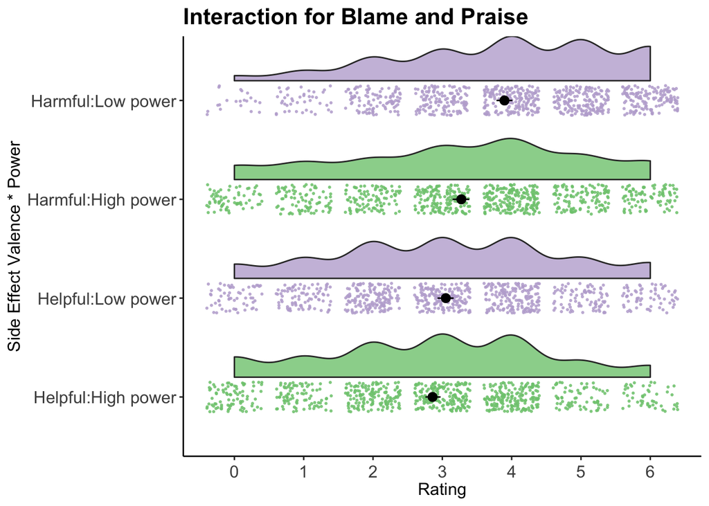

```r
# These two lines create the filters for (1) Blame/Praise and (2) Intentionality for plotting
filterPB2 <-PlotData$Question == "pb"
filterInt2 <-PlotData$Question == "int"

# This is the code for the raincloud plots
source("https://gist.githubusercontent.com/benmarwick/2a1bb0133ff568cbe28d/raw/fb53bd97121f7f9ce947837ef1a4c65a73bffb3f/geom_flat_violin.R")
raincloud_theme = theme(text = element_text(size = 12), axis.title.x = element_text(size = 12),
                        axis.title.y = element_text(size = 12), axis.text = element_text(size = 12),
                        axis.text.x = element_text(vjust = 0.5), legend.title = element_text(size = 12),
                        legend.text = element_text(size=12), legend.position = "right",
                        plot.title = element_text(lineheight=.8, face = "bold", size = 16),
                        panel.border = element_blank(), panel.grid.minor = element_blank(),
                        panel.grid.major = element_blank(),
                        axis.line.x = element_line(colour = 'black', size = 0.5, linetype = 'solid'),
                        axis.line.y = element_line(colour = 'black', size = 0.5, linetype = 'solid'))

# This is the code to create the raincloud plot for the Blame/Praise data
PBRain <- ggplot(data = PlotData[filterPB2,],
                 aes(y = Rating, x = PlotData[filterPB2,]$SEValence : PlotData[filterPB2,]$Power,
                     fill = Power)) +
  geom_flat_violin(position = position_nudge(x = .2, y = 0), alpha = .8, trim=TRUE) +
  geom_point(aes(y = Rating, color = Power),
             position = position_jitter(width = .15), size = .4, alpha = 0.8) +
  expand_limits(x = 3) +
  guides(fill = FALSE) +
  guides(color = FALSE) +
  scale_color_brewer(palette = "Accent") +
  scale_fill_brewer(palette = "Accent") +
  coord_flip() + theme_bw() +
  raincloud_theme +
  labs(x = "Side Effect Valence * Power", title = "Interaction for Blame and Praise") +
  scale_y_continuous(breaks = seq(0,6,by = 1)) +
  stat_summary(fun.data = "mean_cl_boot", colour = "black", size = .5)

PBRain
```

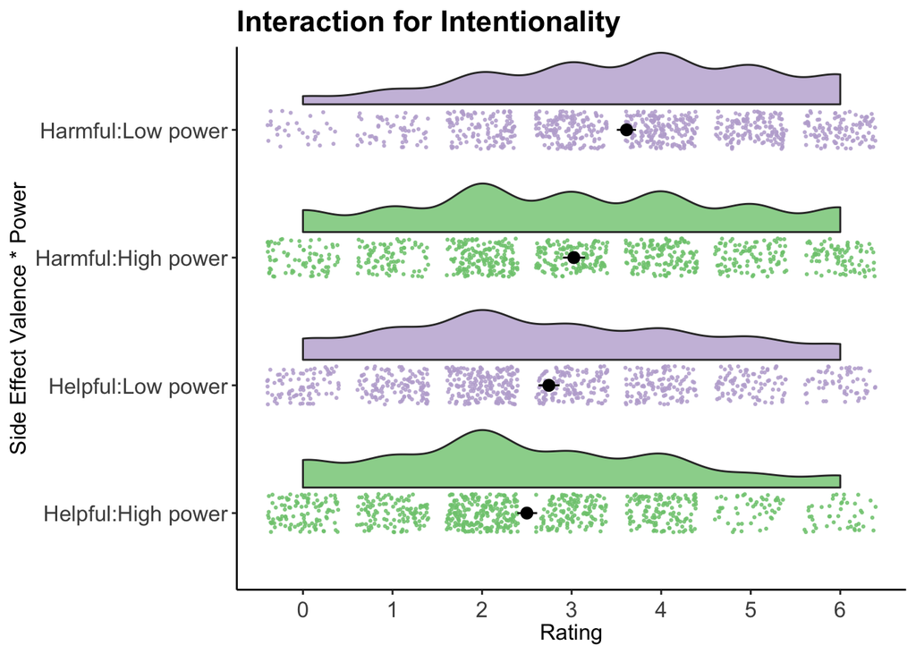

```r
# This is the raincloud plot for the Intentionality model
IntRain <- ggplot(data = PlotData[filterInt2,],
                 aes(y = Rating, x = PlotData[filterInt2,]$SEValence : PlotData[filterInt2,]$Power, fill = Power)) +
  geom_flat_violin(position = position_nudge(x = .2, y = 0), alpha = .8, trim=TRUE) +
  geom_point(aes(y = Rating, color = Power),
             position = position_jitter(width = .15), size = .4, alpha = 0.8) +
  expand_limits(x = 3) +
  guides(fill = FALSE) +
  guides(color = FALSE) +
  scale_color_brewer(palette = "Accent") +
  scale_fill_brewer(palette = "Accent") +
  coord_flip() +
  theme_bw() +
  raincloud_theme +
  labs(x = "Side Effect Valence * Power", title = "Interaction for Intentionality") +
  scale_y_continuous(breaks = seq(0,6,by = 1)) +
  stat_summary(fun.data = "mean_cl_boot", colour = "black", size =.5)

IntRain
```

# Research Team

This research was conducted by [Bradley Kennedy](https://bradk.co.uk)  
Principal Supervisor: Dr Suzanne L. K. Stewart  
Supervision Team: Dr Annie Scudds & Professor Moira Lafferty

[figure not shown]